# Accept-Reject Algorithm

Author

Jiachen Ai; UID: 206182615

## Problem Statement

You are given a probability density function (PDF) $f(x)$ that you wish to sample from:

$$f(x) = \frac{3}{8} x^2, \quad \text{for } x \in [0, 2].$$

1. **Proposal Distribution:** Use a uniform distribution $g(x) = \frac{1}{2}$ on the interval $[0, 2]$ as the proposal distribution.

**Answer**:

The proposal distribution $g(x)$ is a uniform distribution on the interval $[0, 2]$, which can be expressed as:
$$g(x) = \frac{1}{2}, \quad \text{for } x \in [0, 2].$$

2. **Determine** $c$: Find an appropriate value for $c$ such that $c g(x) \geq f(x)$ for all $x \in [0, 2]$.

**Answer**:

To determine the value of $c$, we need to find the maximum value of $\frac{f(x)}{g(x)}$ for $x \in [0, 2]$.

Given: $f(x) = \frac{3}{8} x^2$ and $g(x) = \frac{1}{2}$

We have: $\frac{f(x)}{g(x)} = \frac{\frac{3}{8} x^2}{\frac{1}{2}} = \frac{3}{4} x^2$

To find the maximum value of $\frac{f(x)}{g(x)}$, we take the derivative with respect to $x$ and set it equal to zero: $\frac{d}{dx} \left( \frac{3}{4} x^2 \right) = \frac{3}{2} x = 0$

Solving for $x$, we get $x = 0$. Since $\frac{f(x)}{g(x)}$ is monotonically increasing for $x \in [0, 2]$, the maximum value occurs at $x = 2$. Therefore, the maximum value of $\frac{f(x)}{g(x)}$ is: $\frac{f(2)}{g(2)} = \frac{\frac{3}{8} \cdot 2^2}{\frac{1}{2}} = 3$

Thus, we choose $c = 3$ such that $c g(x) \geq f(x)$ for all $x \in [0, 2]$.

3. **Implement the Accept-Reject Algorithm:** Write out the steps of the accept-reject algorithm for generating random samples from $f(x)$ using the proposal distribution $g(x)$ and the value of $c$ you determined.

**Answer**:

The Accept-Reject Algorithm for generating random samples from $f(x)$ using the proposal distribution $g(x)$ and $c = 3$ is as follows:

1. Generate a random sample $x$ from the uniform distribution $g(x) = \frac{1}{2}$ on the interval $[0, 2]$.
2. Generate a random sample $u$ from the uniform distribution on the interval $[0, 1]$.
3. Calculate the acceptance probability $A(x) = \frac{f(x)}{c g(x)} = \frac{\frac{3}{8} x^2}{3 \cdot \frac{1}{2}} = \frac{1}{4} x^2$.
4. If $u \leq A(x)$, accept the sample $x$; otherwise, reject the sample.
5. Repeat steps 1-4 until the desired number of samples is generated.

The acceptance rate of the accept-reject algorithm can be calculated as the ratio of accepted samples to the total number of samples generated.

4. **Simulate Samples (Programming):** Using R, simulate 1000 random samples from the distribution $f(x)$. Plot a histogram of the generated samples along with the true density $f(x)$.

**Answer**:

First, we define the accept-reject function in R that implements the accept-reject algorithm using the proposal distribution $g(x)$ which is uniform on $[0, 2]$ and the value of $c = 3$.

```r
accept_reject <- function(fx, n) {

  # Simulates a sample of size n from the pdf fx
  # using the accept-reject algorithm
  x <- numeric(n)
  count <- 0
  iterations <- 0  # track the number of iterations
  # create a list to store the result
  list <- list()

  while (count < n) {

    # Generate a random sample from the proposal distribution
    # g(x) which is uniform on [0, 2]
    temp <- runif(1, 0, 2)

    # Generate uniform random value to decide
    # whether to accept or reject the candidate sample
    y <- runif(1, 0, 1)

    iterations <- iterations + 1  # Increment the iteration counter

    if (y < fx(temp)) {
      count <- count + 1
      x[count] <- temp
    }
  }

  return(list(samples = x, iterations = iterations))
}
```

Next, we simulate 100000 random samples from the distribution $f(x)$.

```r
# Define the acceptance probability function A(x) = f(x) / c g(x)
Ax <- function(x) {
  return(1/4 * x^2)
}

# Define the true density function f(x)
fx <- function(x) {
  return(3/8 * x^2)
}


# Simulate 100000 random samples from the distribution f(x)
set.seed(2024)
samples <- accept_reject(Ax, n = 100000)
```

Finally, we plot a histogram of the generated samples along with the true density $f(x)$.

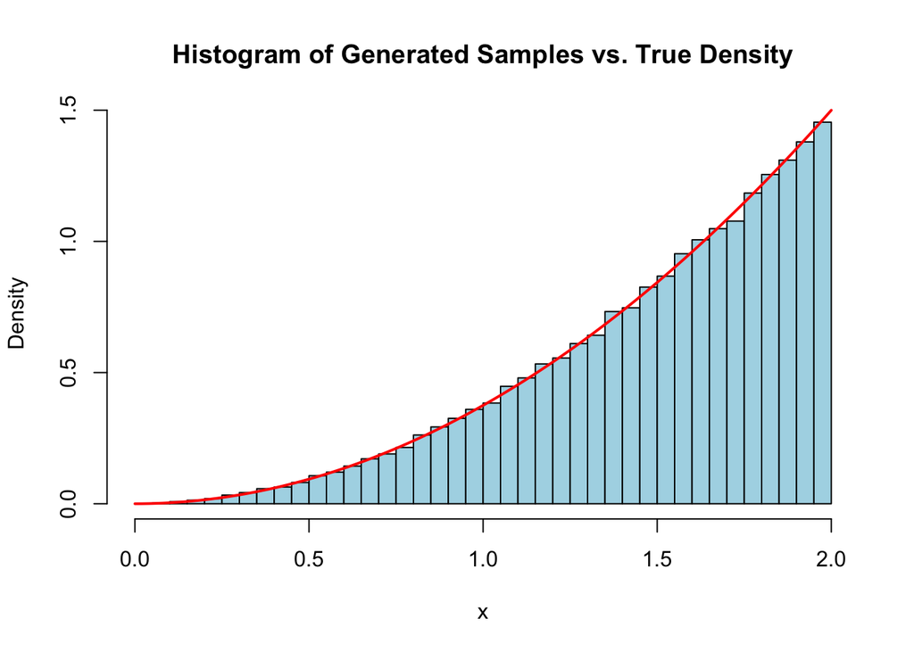

```r
# Plot histogram of the generated samples
hist(samples$samples, freq = FALSE, breaks = 50, col = "lightblue",
     main = "Histogram of Generated Samples vs. True Density",
     xlab = "x", ylab = "Density")

# Add the true density f(x) to the plot
curve(fx(x), add = TRUE, col = "red", lwd = 2)
```

**Evaluate Efficiency:**

**Answer**:

The acceptance rate of the accept-reject algorithm can be calculated as the ratio of accepted samples to the total number of samples generated. In this case, the acceptance rate can be calculated as follows:

```r
# Calculate the acceptance rate
acceptance_rate <- length(samples$samples) / samples$iterations
acceptance_rate
```

```
[1] 0.3343755
```

**Bonus - Alternative Proposal Distribution:** Suggest an alternative proposal distribution $g(x)$ that could improve the acceptance rate of the algorithm. Justify why this choice might be better.

**Answer**:

In order to improve the acceptance rate of the accept-reject algorithm, we need to choose a proposal distribution $g(x)$ that closely approximates the target distribution $f(x)$.

```r
# Accept-Reject function using Beta distribution
accept_reject <- function(fx, n) {

  # Simulates a sample of size n from the pdf fx
  # using the accept-reject algorithm
  x <- numeric(n)
  count <- 0
  iterations <- 0  # track the number of iterations

  while (count < n) {

    # Generate a random sample from the Beta(3, 1) distribution,
    # and rescale it to the interval [0, 2]
    temp <- rbeta(1, 2, 1) * 2

    # Generate uniform random value to decide
    # whether to accept or reject the candidate sample
    y <- runif(1, 0, 1)

    iterations <- iterations + 1  # Increment the iteration counter

    # Check if we accept the sample based on the acceptance probability
    if (y < fx(temp)) {
      count <- count + 1
      x[count] <- temp
    }
  }

  return(list(samples = x, iterations = iterations))
}
```

```r
# Define the acceptance probability function A(x) = f(x) / c g(x)
Ax <- function(x) {
  return(1/4 * x^2)
}

# Simulate 100000 random samples from the distribution f(x)
set.seed(2024)
result <- accept_reject(Ax, n = 100000)
```

Finally, we plot a histogram of the generated samples along with the true density $f(x)$.

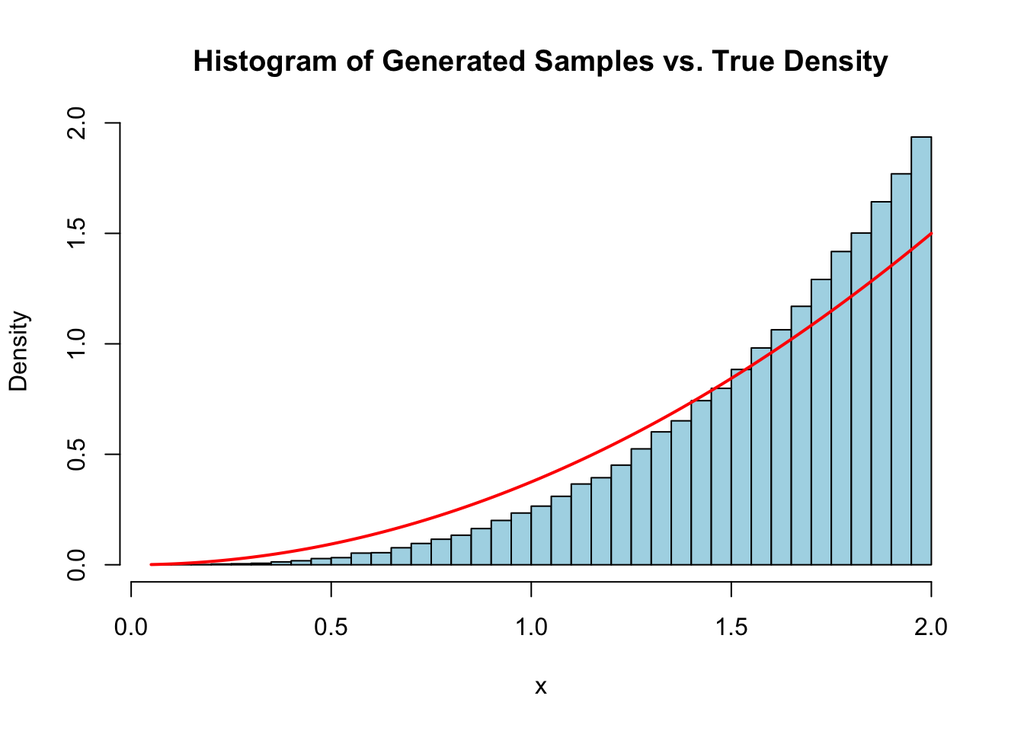

```r
# Plot histogram of the generated samples
hist(result$samples, freq = FALSE, breaks = 50, col = "lightblue",
     main = "Histogram of Generated Samples vs. True Density",
     xlab = "x", ylab = "Density")

# Add the true density f(x) to the plot
curve(fx(x), add = TRUE, col = "red", lwd = 2)
```

Evaluate Efficiency:

```r
# Calculate the acceptance rate
acceptance_rate <- length(result$samples) / result$iterations
acceptance_rate
```

```
[1] 0.498671
```